# classification.py

```python
# import necessary libraries
import pandas as pd
import numpy as np
import seaborn as sns
import matplotlib.pyplot as plt
from sklearn.preprocessing import StandardScaler
from sklearn.decomposition import PCA
# from scipy import stats
from numpy import mean
from numpy import std
from sklearn.model_selection import train_test_split, cross_validate, RepeatedStratifiedKFold
from sklearn.discriminant_analysis import LinearDiscriminantAnalysis
from sklearn.ensemble import RandomForestClassifier
from sklearn.metrics import f1_score, plot_confusion_matrix, precision_score, recall_score, accuracy_score

import warnings

warnings.simplefilter('ignore')
```

```python
# Read the training data and drop column 'Unnamed: 0'
data = pd.read_csv("Arya_DataScientist_Assignment/training_set.csv")
data.drop('Unnamed: 0', axis=1, inplace=True)
```

```python
# Print shape of data
data.shape
```

```
(3910, 58)
```

```python
data.head()
```

|  | X1 | X2 | X3 | X4 | X5 | X6 | X7 | X8 | X9 | X10 | ... | X49 | X50 | X51 | X52 | X53 | X54 | X55 | X56 | X57 | Y |
| --- | --- | --- | --- | --- | --- | --- | --- | --- | --- | --- | --- | --- | --- | --- | --- | --- | --- | --- | --- | --- | --- |
| 0 | 0.00 | 0.00 | 4.34 | 0.00 | 0.00 | 0.00 | 0.00 | 0.00 | 0.0 | 0.00 | ... | 0.0 | 0.000 | 0.0 | 1.342 | 0.000 | 0.000 | 1.200 | 2 | 12 | 0 |
| 1 | 0.00 | 0.56 | 0.56 | 0.00 | 1.12 | 0.56 | 2.25 | 0.00 | 0.0 | 0.56 | ... | 0.0 | 0.083 | 0.0 | 0.503 | 0.000 | 0.083 | 16.304 | 148 | 375 | 1 |
| 2 | 0.00 | 0.00 | 0.00 | 0.00 | 0.00 | 0.00 | 0.00 | 0.00 | 0.0 | 0.00 | ... | 0.0 | 0.000 | 0.0 | 0.000 | 0.000 | 0.000 | 1.000 | 1 | 5 | 0 |
| 3 | 0.64 | 0.00 | 0.64 | 0.00 | 1.93 | 0.00 | 0.00 | 0.00 | 0.0 | 0.00 | ... | 0.0 | 0.000 | 0.0 | 0.462 | 0.370 | 0.000 | 2.440 | 22 | 122 | 1 |
| 4 | 0.58 | 0.00 | 0.00 | 35.46 | 0.58 | 0.00 | 0.58 | 0.58 | 0.0 | 0.00 | ... | 0.0 | 0.000 | 0.0 | 0.239 | 0.239 | 0.000 | 3.338 | 123 | 207 | 1 |

5 rows × 58 columns

### Check data info

```python
data.info()
```

```
<class 'pandas.core.frame.DataFrame'>
RangeIndex: 3910 entries, 0 to 3909
Data columns (total 58 columns):
 #   Column  Non-Null Count  Dtype
---  ------  --------------  -----
 0   X1      3910 non-null   float64
 1   X2      3910 non-null   float64
 2   X3      3910 non-null   float64
 3   X4      3910 non-null   float64
 4   X5      3910 non-null   float64
 5   X6      3910 non-null   float64
 6   X7      3910 non-null   float64
 7   X8      3910 non-null   float64
 8   X9      3910 non-null   float64
 9   X10     3910 non-null   float64
```

[output cut: 50 more lines]

1. No categorical column in dataset
2. 57 predictors
3. 3910 total entries
4. No null values in any column

### Check for null values

```python
data.isna().sum()
```

```
X1     0
X2     0
X3     0
X4     0
X5     0
X6     0
X7     0
X8     0
X9     0
X10    0
X11    0
X12    0
X13    0
X14    0
X15    0
X16    0
X17    0
X18    0
X19    0
X20    0
X21    0
X22    0
X23    0
X24    0
X25    0
X26    0
X27    0
X28    0
X29    0
X30    0
X31    0
X32    0
X33    0
X34    0
X35    0
X36    0
X37    0
X38    0
X39    0
X40    0
X41    0
X42    0
X43    0
X44    0
X45    0
X46    0
X47    0
X48    0
X49    0
X50    0
X51    0
X52    0
X53    0
X54    0
X55    0
X56    0
X57    0
Y      0
dtype: int64
```

There are no null values in the dataset

### Check distribution of target variable

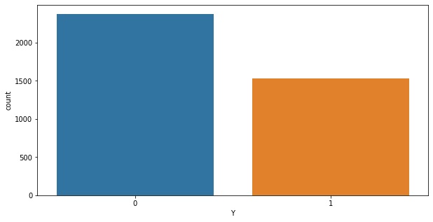

```python
# Check for count of two target classes in dataset
plt.figure(figsize=(10,5))
sns.countplot(x="Y", data=data)
```

Number of instances with class '0' is more than class '1'

```python
print("Percentage of data with class 0 is {0:.2f}".format(data[data['Y']==0].shape[0]*100/data.shape[0]))
print("Percentage of data with class 1 is {0:.2f}".format(data[data['Y']==1].shape[0]*100/data.shape[0]))
```

```
Percentage of data with class 0 is 60.77
Percentage of data with class 1 is 39.23
```

### Check correlation amongst the variables

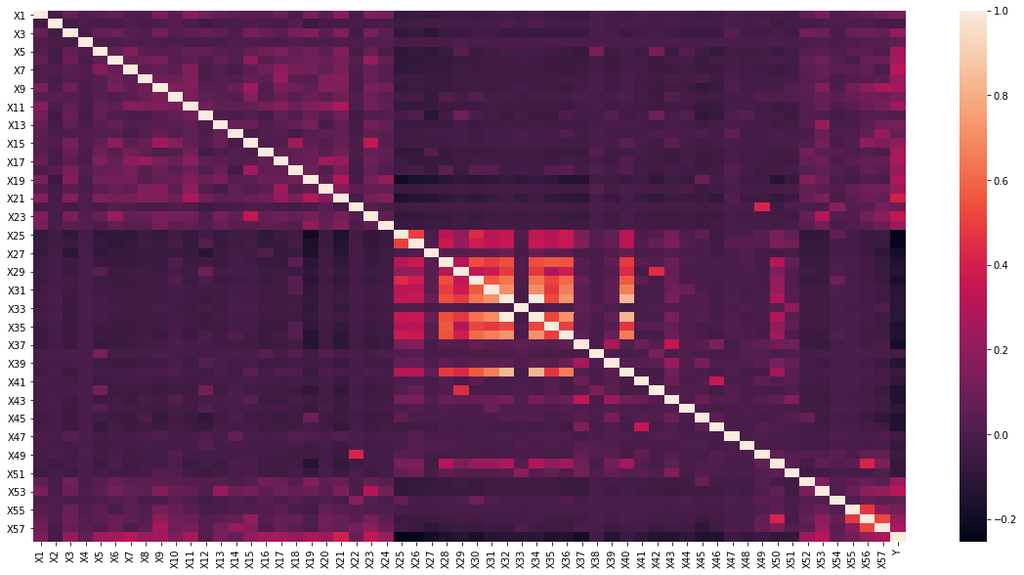

```python
plt.figure(figsize=(20,10))
sns.heatmap(data.corr())
```

Clearly from the above heat map, degree of correlation amongst predictors is very less. Hence, Principal Componnet Analysis might not perform well in this case.

#### Check correlation with target variable

```python
target_corr = data.corr()['Y']
target_corr = target_corr[(target_corr>=0.5) | (target_corr<=-0.5)]
print("Columns with correlation with target variable: ",target_corr.index.tolist()[:-1])
print("\nCorrelation:")
print(target_corr)
```

```
Columns with correlation with target variable:  []

Correlation:
Y    1.0
Name: Y, dtype: float64
```

### Check skewness in data

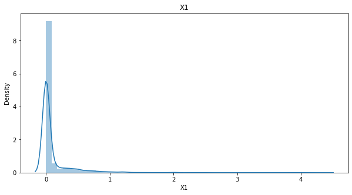

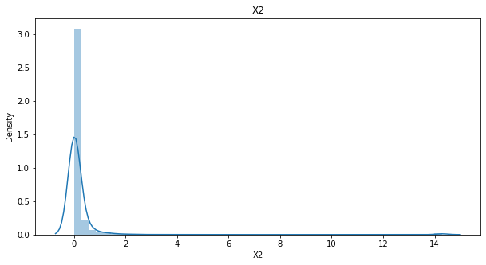

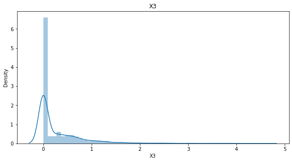

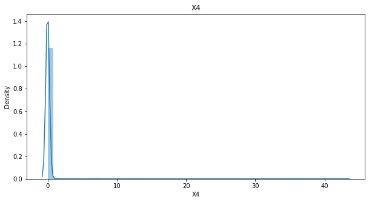

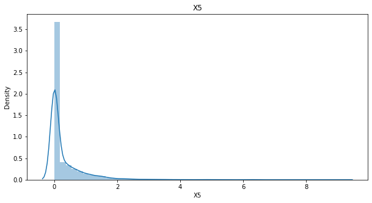

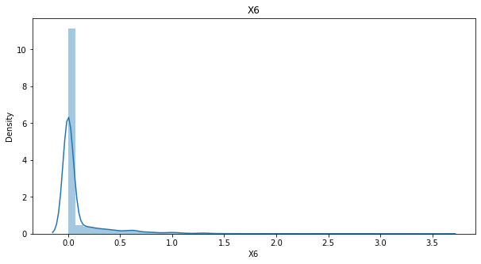

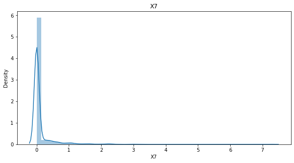

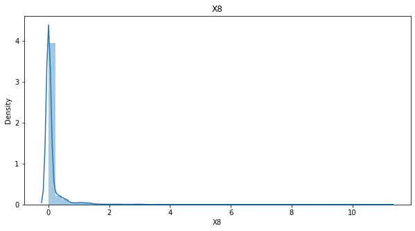

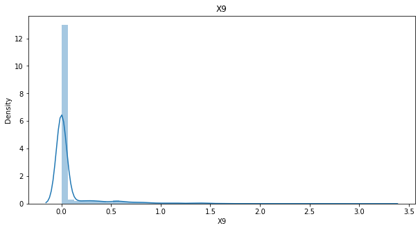

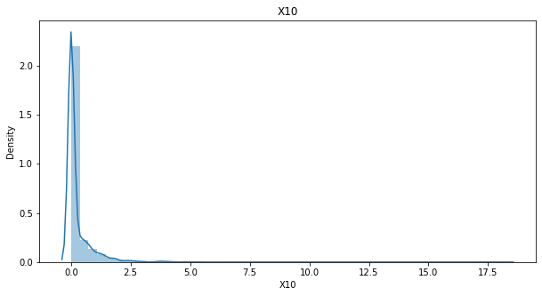

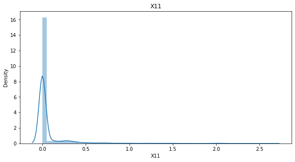

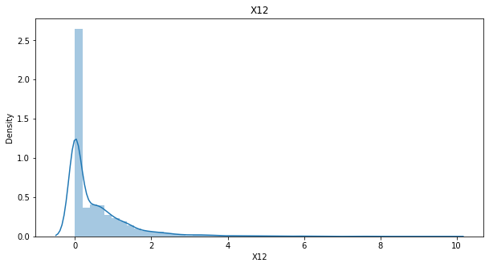

[45 more figures not shown]

```python
# Code to show skewness in data

for i, col in enumerate(data.drop('Y',axis=1).columns):
    plt.figure(figsize=(10,5))
    sns.distplot(data[col])
    plt.title(col)
```

From above diagrams it can be clearly seen that all the variables are positively skewed. Hence we perform some tranformations to remove skewness.

### Transform data to remove skewness

```python
log_transform = np.median(((data.drop(['Y'], axis=1).skew()- np.log1p(data.drop(['Y'], axis=1)).skew())*100/(data.drop('Y', axis=1).skew())).values)
sqrt_transform = np.median(((data.drop('Y', axis=1).skew()- np.sqrt(data.drop(['Y'], axis=1)).skew())*100/(data.drop('Y', axis=1).skew())).values)

print("Percentage reduction in skewness due to log transform is {0:.2f}".format(log_transform))
print("Percentage reduction in skewness due to sqrt transform is {0:.2f}".format(sqrt_transform))
```

```
Percentage reduction in skewness due to log transform is 44.08
Percentage reduction in skewness due to sqrt transform is 57.33
```

Hence we use transform data using sqrt transform

### Transform data using sqrt tranform

```python
feature_col = data.drop('Y', axis=1).columns
data[feature_col] = np.sqrt(data[feature_col])
```

### 1. Separate X and y

```python
# Separating out the features
X = data.drop('Y', axis=1)

# Separating out the target
y = data['Y']
```

### 2. Train test split

```python
X_train, X_test, y_train, y_test = train_test_split(X, y, test_size=0.25, random_state=42)
```

### 3. Standardize dataset

```python
# Standardizing the features
scaler = StandardScaler()
scaler.fit(X_train)
X_train_std = scaler.transform(X_train)
X_test_std = scaler.transform(X_test)
```

#### As we had seen there is very less correlation amongst predictor variables. Hence PCA will not perform better on this dataset.

### PCA

#### Let's fit PCA with n_components = no of features in dataset which is 57

```python
pca = PCA(n_components=57)
pca.fit(X_train_std)
```

```
PCA(n_components=57)
```

#### Plot variance explained by components

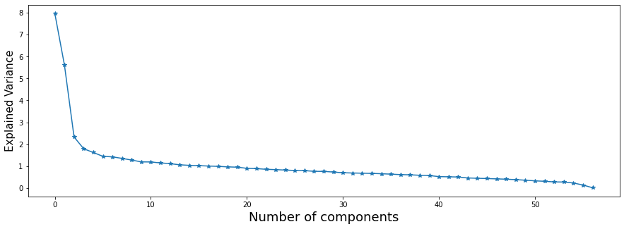

```python
plt.figure(figsize=(15,5))
plt.plot(range(len(pca.explained_variance_ratio_)),pca.explained_variance_,'*-')
plt.xlabel("Number of components",fontsize=18)
plt.ylabel("Explained Variance",fontsize=15)
```

From above graph, we can see that variance explained by number of components>10 is very less. We can take n=10 components for PCA

#### Plot cumulative variance explained by components

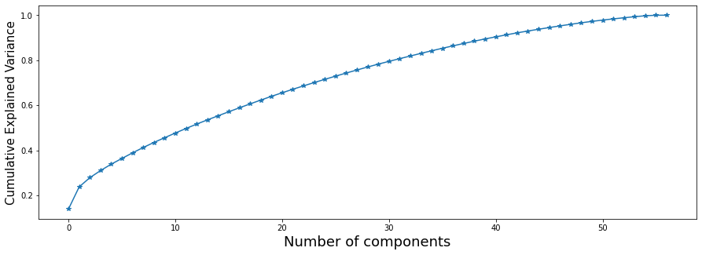

```python
plt.figure(figsize=(15,5))
plt.plot(range(len(pca.explained_variance_ratio_)),pca.explained_variance_ratio_.cumsum(),'*-')
plt.xlabel("Number of components",fontsize=18)
plt.ylabel("Cumulative Explained Variance",fontsize=15)
```

#### Fit PCA

```python
n_components = 10
pca = PCA(n_components=n_components)
pca.fit(X_train_std)
print("Percentage variance explained by {0} components is {1:.2f}%".format(n_components, 100*pca.explained_variance_ratio_.sum()))
```

```
Percentage variance explained by 10 components is 45.54%
```

```python
principalComponents = pca.transform(X_train_std)
principalDf = pd.DataFrame(principalComponents)

principalComponents_test = pca.transform(X_test_std)
principalDf_test = pd.DataFrame(principalComponents_test)
```

#### Use Random forest classifier

```python
# evaluate a lda model on the dataset

# define model
model = RandomForestClassifier(random_state=100)

# define model evaluation method
cv = RepeatedStratifiedKFold(n_splits=10, n_repeats=3, random_state=1)

# evaluate model
scores = cross_validate(model, principalDf, y_train, scoring=['accuracy', 'f1'], cv=cv, n_jobs=-1)

# summarize result
print('Mean Accuracy: %.3f' % (mean(scores['test_accuracy'])))
print('F1 score: %.3f' % (mean(scores['test_f1'])))
```

```
Mean Accuracy: 0.938
F1 score: 0.921
```

```python
model.fit(principalComponents, y_train)
y_pred = model.predict(principalComponents_test)

print("F1 score on validation set is {0:.2f}".format(f1_score(y_test, y_pred)))
```

```
F1 score on validation set is 0.92
```

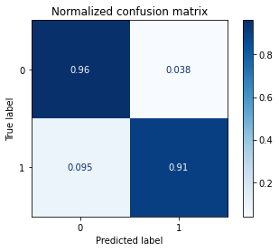

```
Accuracy: 0.94
F1 Score: 0.92
Recall Score: 0.91
Precision Score: 0.94
```

```python
class_names = y.unique()


np.set_printoptions(precision=2)

# Plot non-normalized confusion matrix
disp = plot_confusion_matrix(model, principalComponents_test, y_test,
                             display_labels=class_names,
                             cmap=plt.cm.Blues,
                             normalize='true')
disp.ax_.set_title("Normalized confusion matrix")
plt.show()

print("Accuracy: {0:.2f}".format(accuracy_score(y_test, y_pred)))
print("F1 Score: {0:.2f}".format(f1_score(y_test, y_pred)))
print("Recall Score: {0:.2f}".format(recall_score(y_test, y_pred)))
print("Precision Score: {0:.2f}".format(precision_score(y_test, y_pred)))
```

### From above results, not only accuracy of model is high but precision and recall scores are also good which indicates that model performance is not biased towards any class and FP and FN are also very less.

## Predictions on test data

```python
# Read test data file
test_data = pd.read_csv("Arya_DataScientist_Assignment/test_set.csv")
test_data.drop('Unnamed: 0', axis=1, inplace=True)

# Transformation for removing skewness
test_data[feature_col] = np.sqrt(test_data[feature_col])

# Standardize the data
test_data_std = scaler.transform(test_data)

# PCA
test_data_principalComponents = pca.transform(test_data_std)
test_data_principalDf = pd.DataFrame(test_data_principalComponents)

# Prediction
test_data_pred = pd.DataFrame(model.predict(test_data_principalDf), columns=['pred'])

# Save results
test_data_pred.to_excel("test_data_pred.xlsx",index=False)

test_data_pred
```

|  | pred |
| --- | --- |
| 0 | 0 |
| 1 | 1 |
| 2 | 1 |
| 3 | 1 |
| 4 | 1 |
| ... | ... |
| 686 | 0 |
| 687 | 0 |
| 688 | 0 |
| 689 | 0 |
| 690 | 0 |

691 rows × 1 columns